# app

**Importing Modules**

Firstly we have to initialize the modules we are going to use. We are going to use the following modules:

```python
import numpy as np
import pandas as pd
from sklearn.model_selection import train_test_split
from sklearn.linear_model import LinearRegression
import matplotlib.pyplot as plt
```

**Reading CSV Files**

We are going to read the csv files using the pandas module. We are going to read the following files:

```python
dataset=pd.read_csv('data.csv')
dataset
```

|  | item_code | price |
| --- | --- | --- |
| 0 | 4 | 420 |
| 1 | 5 | 440 |
| 2 | 6 | 480 |
| 3 | 7 | 500 |
| 4 | 8 | 520 |
| 5 | 9 | 540 |
| 6 | 10 | 560 |
| 7 | 11 | 580 |
| 8 | 12 | 600 |
| 9 | 13 | 620 |
| 10 | 14 | 640 |
| 11 | 15 | 660 |
| 12 | 15 | 700 |

**Head() of the Data**

We are going to take a look at the head of the data to see how the data looks like.

```python
dataset.head(4)
```

|  | item_code | price |
| --- | --- | --- |
| 0 | 4 | 420 |
| 1 | 5 | 440 |
| 2 | 6 | 480 |
| 3 | 7 | 500 |

**Shape of the Data**

We are going to take a look at the shape of the data to see how many rows and columns the data has.

```python
dataset.shape
```

```
(13, 2)
```

**IsNull().any()**

We are going to take a look at the isnull values of the data to see if there are any missing values in the data.

```python
dataset.isnull().any()
```

```
item_code    False
price        False
dtype: bool
```

**Store item_code and price in variables**

We are going to store the item_code and price in variable x and y respectively.

```python
x=dataset[['item_code']]
y=dataset[['price']]
```

**Plotting the Data**

We are going to plot the data using the matplotlib module.

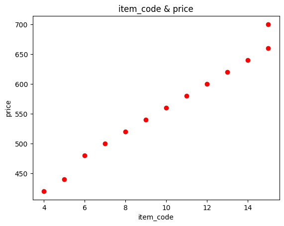

```python
plt.scatter(x,y,marker='o',color='red')
plt.title('item_code & price')
plt.xlabel('item_code')
plt.ylabel('price')
plt.show()
```

**Data Splitting**

We are going to split the data.

```python
xtrain,xtest,ytrain,ytest=train_test_split(x,y,test_size=.30,random_state=1)
xtrain
```

|  | item_code |
| --- | --- |
| 1 | 5 |
| 6 | 10 |
| 0 | 4 |
| 7 | 11 |
| 12 | 15 |
| 9 | 13 |
| 8 | 12 |
| 11 | 15 |
| 5 | 9 |

**Applying Linear Regression**

We are going to apply linear regression on the data.

```python
reg=LinearRegression()
reg.fit(xtrain,ytrain)
reg.predict(xtest)
ytest
```

|  | price |
| --- | --- |
| 2 | 480 |
| 3 | 500 |
| 4 | 520 |
| 10 | 640 |

**Plot the Regression Line**

We are going to plot the regression line.

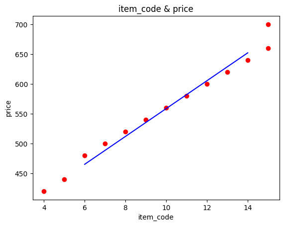

```python
plt.scatter(x,y,marker='o',color='red')
plt.title('item_code & price')
plt.xlabel('item_code')
plt.ylabel('price')
plt.plot(xtest,reg.predict(xtest),color='blue')
```

**Predicting the Price**

We are going to predict the price of the item.

```python
reg.predict([[45]])
```

```
array([[1376.83363148]])
```

**Coef_ and Intercept_**

We are going to take a look at the coef_ and intercept_ of the model.

```python
reg.coef_
```

```
array([[23.38103757]])
```

```python
reg.intercept_
```

```
array([324.68694097])
```